# Class 11: Social Movements online, in effect, dying out, and going forward

Online

Author

[Dr. Michael C. Zeller](https://michaelzeller.de)

# Opening notes

[Open Sticker](https://tenor.com/view/open-gif-14209777)from [Open Stickers](https://tenor.com/search/open-stickers)

- **short synopsis** for final essay due **Friday (17 January)** (send to me via email)

## Presentation groups

Presentations line-up

| Date | Presenters | Method |
| --- | --- | --- |
| 14 Dec: |  | TBD |

# Theses from an earlier age of the internet (Diani 2000)

- ‘computer mediated communication’ (CMC)
- types of communication
- features of internet tools
- different organisation types and CMC

[Wlan GIF](https://tenor.com/view/wlan-gif-12418525811703301139)from [Wlan GIFs](https://tenor.com/search/wlan-gifs)

## Diani (2000) - CMC

‘computer mediated communication’, **CMC**:

- interpersonal communication through the use of computers or digital devices, now typically involving internet channels
  - then: (mass) email, message boards, instant messaging
  - now: social media, encrypted messaging with different message types (photo, video, audio), AI-generated material, other ways??

. . .

- sometimes easing how people communicate; sometimes changing it

## Diani (2000) - types of communication

|  | Private | Public |
| --- | --- | --- |
| Direct | --face-to-face between activists | --in public spaces (e.g., demos) |
|  | --message restricted to group boundaries | --communicating to person(s) (e.g., speeches, leafleting) |
|  |  | --may overlap with attempts to attract media attention (i.e. ’public mediated’) |
| Mediated | --messages within group boundaries but transmitted through tech | --all media-related communication (e.g., press releases, adverts, 'manipulation of media through spectacular events') |
|  | --(e.g., email, phone calls) with varying privacy |  |

## Features and facets of internet tools

- Accessibility: public *or* ‘private’
  - open access or restricted
    - also, ‘digital divide’: many have no/less access to modern digital communication tools
- Temporality: asynchronous *or* synchronous
  - real-time, live *or* delayed
  - temporary *or* permanent
- Identity: ‘in-real-life’ identity / anonymity / pseudonymity
  - same social stigmas as elsewhere *or* disinhibition
- Algorithmic effects: present *or* not (and in what degree)
  - amplification / suppression / no role
  - trending?
  - echo chambers? filter bubbles?
- Platform regulation: present *or* not (and in what degree)
  - platform policies and content moderation
  - state/regulator requirements
- other features?

## Diani (2000) - organisations and communication

some hypotheses about CMC and different movement organisations

| Organisation type | Importance of CMC | Effects? |
| --- | --- | --- |
| Orgs. focusing on professional resources | high | CMC supports professionalised groups that sometimes require large mobilisation (e.g., Greenpeace), helping to 'get the word out' |
| Orgs. mobilising participatory resources | moderate/low | CMC reinforces already existing ties; these orgs. remain reliant on direct, face-to-face interactions to recruit, build collective identity, and maintain commitment |
| Orgs. mobilising participatory resources | moderate/low | "Sustained collective action is unlikely to originate from purely virtual ties if they are not sustained by previous interaction" |
| Transnational networks | moderate | CMC helps link (especially former) activists and militants (individuals and groups) to promote shared values, but little consequential effect for organising |

## Diani (2000) - theses of an earlier internet age

Broadly, internet tools (‘computer mediated communication’, **CMC**) allow…

. . .

- greater speed (and accuracy) of communication

. . .

- less cost of communication

. . .

- greater connectivity across distances
  - unifying different national or regional parts of a movement

. . .

Are these assertions still ‘as true’ as they were in 2000?

## Diani (2000) - theses of an earlier internet age

Can CMC create new types of communities (if so, what kinds)? Can they create collective identity and enable **durable**/**sustained** activism?

. . .

- can that happen with online anonymity?

> most examples of personal interaction in electronic discussion groups actually miss some of the requirements usually associated with the idea of community. Participants in those lists often hide their personal identity, participate occasionally, are not tied in any sort of committed relationship and **are mostly involved in dyadic or at most triadic interactions**

# Poll: Movements online

[figure not shown]

Take the survey at **https://forms.gle/xwWefHu7eDAmyzvv9**

- most important online tool for SMs?
- online organising more democratic?
- online movements more individualised?
- platforms amplify movements of the marginalised?
- platforms not useful: algorithms favour sensationalism?
- online activity often encourages “slacktivism”
- movements online face greater surveillance?
- should online platforms be more regulated to prevent movements spreading misinformation?

Questions about movements: (1) online activity important to the movement? (2) most important use of online tools for this movement? (3) new supporters first encounter movement online? (4) online participation often leads to offline participation? (5) most important platform for the movement? (6) movement has been affected by content moderation policies? (7) online participation gives supporters a sense of belonging?

```javascript
md`## Poll results (Respondents: ${respondentCount})`
```

[interactive chart not shown]

```javascript
import { liveGoogleSheet } from "@jimjamslam/live-google-sheet";
import { aq, op } from "@uwdata/arquero";

// UPDATE THE LINK FOR A NEW POLL
surveyResults = liveGoogleSheet(
  "https://docs.google.com/spreadsheets/d/e/" +
    "2PACX-1vR7--DC-gLwhLrMYBIvigczwsp5vMxC5A93sY7PDai0NdSIBFSvjTOjKUZxxtLpl9KWTxiyxKPAGtUD/" +
    "pub?gid=2023133127&single=true&output=csv",
  10000, 1, 17); // adjust the last number to select all relevant columns

respondentCount = surveyResults.length;

likertOrder = [
  "Strongly disagree",
  "Disagree",
  "Neutral",
  "Agree",
  "Strongly agree"
];

ynmOrder = [
  "Yes",
  "No",
  "Maybe"
];

movementOrder = [
  "Antifa",
  "FFF",
  "LG",
  "PEGIDA",
  "Identitarians",
  "Querdenker"
];

movementColors = [
  "black",
  "green",
  "darkorange",
  "red",
  "gold",
  "purple"
];
```

[interactive chart not shown]

online organising more democratic?

```javascript
more_democraticCounts = aq.from(surveyResults)
  .select("more_democratic")
  .groupby("more_democratic")
  .count()
  .derive({ measure: d => "" })

// Calculate the maximum count from your dataset
more_democratic_maxCountRE = Math.max(...more_democraticCounts.objects().map(d => d.count));

plot_more_democratic = Plot.plot({
  marks: [
    Plot.barY(more_democraticCounts, {
      x: "more_democratic",
      y: "count",
      fill: "more_democratic",
      stroke: "black",
      strokeWidth: 1
    }),
    Plot.ruleY([respondentCount], { stroke: "#ffffff99" })
  ],
  color: {
    domain: [
      "Strongly disagree",
      "Disagree",
      "Neutral",
      "Agree",
      "Strongly agree"
    ],
    range: [
      "red",
      "pink",
      "lightgrey",
      "lightgreen",
      "forestgreen"
    ]
  },
  marginBottom: 180,
  x: { label: "", tickSize: 2, tickRotate: -45,
    domain: ["Strongly disagree", "Disagree", "Neutral", "Agree", "Strongly agree"]
  },
  y: {
    label: "",
    tickSize: 10,
    tickFormat: d => d,
    tickValues: Array.from(
      new Set(more_democraticCounts.objects().map(d => d.count))
    ).sort((a, b) => a - b),
    domain: [0, more_democratic_maxCountRE]
  },
  facet: { data: more_democraticCounts, x: "measure", label: "" },
  marginLeft: 140,
  style: {
    width: 1350,
    height: 500,
    fontSize: 30,
  }
});
```

[interactive chart not shown]

online movement activity more individualised?

```javascript
individualisedCounts = aq.from(surveyResults)
  .select("individualised")
  .groupby("individualised")
  .count()
  .derive({ measure: d => "" })

// Calculate the maximum count from your dataset
individualised_maxCountRE = Math.max(...individualisedCounts.objects().map(d => d.count));

plot_individualised = Plot.plot({
  marks: [
    Plot.barY(individualisedCounts, {
      x: "individualised",
      y: "count",
      fill: "individualised",
      stroke: "black",
      strokeWidth: 1
    }),
    Plot.ruleY([respondentCount], { stroke: "#ffffff99" })
  ],
  color: {
    domain: [
      "Strongly disagree",
      "Disagree",
      "Neutral",
      "Agree",
      "Strongly agree"
    ],
    range: [
      "red",
      "pink",
      "lightgrey",
      "lightgreen",
      "forestgreen"
    ]
  },
  marginBottom: 180,
  x: { label: "", tickSize: 2, tickRotate: -45,
    domain: ["Strongly disagree", "Disagree", "Neutral", "Agree", "Strongly agree"]
  },
  y: {
    label: "",
    tickSize: 10,
    tickFormat: d => d,
    tickValues: Array.from(
      new Set(individualisedCounts.objects().map(d => d.count))
    ).sort((a, b) => a - b),
    domain: [0, individualised_maxCountRE]
  },
  facet: { data: individualisedCounts, x: "measure", label: "" },
  marginLeft: 140,
  style: {
    width: 1350,
    height: 500,
    fontSize: 30,
  }
});
```

[interactive chart not shown]

## Poll results

platforms amplify movements of the marginalised?

```javascript
amplifyCounts = aq.from(surveyResults)
  .select("amplify")
  .groupby("amplify")
  .count()
  .derive({ measure: d => "" })

// Calculate the maximum count from your dataset
amplify_maxCountRE = Math.max(...amplifyCounts.objects().map(d => d.count));

plot_amplify = Plot.plot({
  marks: [
    Plot.barY(amplifyCounts, {
      x: "amplify",
      y: "count",
      fill: "amplify",
      stroke: "black",
      strokeWidth: 1
    }),
    Plot.ruleY([respondentCount], { stroke: "#ffffff99" })
  ],
  color: {
    domain: [
      "Yes",
      "No",
      "Maybe"
    ],
    range: [
      "forestgreen",
      "darkred",
      "goldenrod"
    ]
  },
  marginBottom: 80,
  x: { label: "", tickSize: 2, tickRotate: -1, padding: 0.2,
    domain: ["Yes", "No", "Maybe"]
  },
  y: {
    label: "",
    tickSize: 10,
    tickFormat: d => d,
    tickValues: Array.from(
      new Set(amplifyCounts.objects().map(d => d.count))
    ).sort((a, b) => a - b),
    domain: [0, amplify_maxCountRE]
  },
  facet: { data: amplifyCounts, x: "measure", label: "" },
  marginLeft: 60,
  style: {
    width: 1600,
    height: 500,
    fontSize: 40,
  },
});
```

[interactive chart not shown]

platforms not so useful since algorithms favour sensationalism?

```javascript
algorithmsCounts = aq.from(surveyResults)
  .select("algorithms")
  .groupby("algorithms")
  .count()
  .derive({ measure: d => "" })

// Calculate the maximum count from your dataset
algorithms_maxCountRE = Math.max(...algorithmsCounts.objects().map(d => d.count));

plot_algorithms = Plot.plot({
  marks: [
    Plot.barY(algorithmsCounts, {
      x: "algorithms",
      y: "count",
      fill: "algorithms",
      stroke: "black",
      strokeWidth: 1
    }),
    Plot.ruleY([respondentCount], { stroke: "#ffffff99" })
  ],
  color: {
    domain: [
      "Strongly disagree",
      "Disagree",
      "Neutral",
      "Agree",
      "Strongly agree"
    ],
    range: [
      "red",
      "pink",
      "lightgrey",
      "lightgreen",
      "forestgreen"
    ]
  },
  marginBottom: 180,
  x: { label: "", tickSize: 2, tickRotate: -45,
    domain: ["Strongly disagree", "Disagree", "Neutral", "Agree", "Strongly agree"]
  },
  y: {
    label: "",
    tickSize: 10,
    tickFormat: d => d,
    tickValues: Array.from(
      new Set(algorithmsCounts.objects().map(d => d.count))
    ).sort((a, b) => a - b),
    domain: [0, algorithms_maxCountRE]
  },
  facet: { data: algorithmsCounts, x: "measure", label: "" },
  marginLeft: 140,
  style: {
    width: 1350,
    height: 500,
    fontSize: 30,
  }
});
```

[interactive chart not shown]

## Poll results

online movement activity often encourages a “slacktivism”

```javascript
slacktivismCounts = aq.from(surveyResults)
  .select("slacktivism")
  .groupby("slacktivism")
  .count()
  .derive({ measure: d => "" })

// Calculate the maximum count from your dataset
slacktivism_maxCountRE = Math.max(...slacktivismCounts.objects().map(d => d.count));

plot_slacktivism = Plot.plot({
  marks: [
    Plot.barY(slacktivismCounts, {
      x: "slacktivism",
      y: "count",
      fill: "slacktivism",
      stroke: "black",
      strokeWidth: 1
    }),
    Plot.ruleY([respondentCount], { stroke: "#ffffff99" })
  ],
  color: {
    domain: [
      "Strongly disagree",
      "Disagree",
      "Neutral",
      "Agree",
      "Strongly agree"
    ],
    range: [
      "red",
      "pink",
      "lightgrey",
      "lightgreen",
      "forestgreen"
    ]
  },
  marginBottom: 180,
  x: { label: "", tickSize: 2, tickRotate: -45,
    domain: ["Strongly disagree", "Disagree", "Neutral", "Agree", "Strongly agree"]
  },
  y: {
    label: "",
    tickSize: 10,
    tickFormat: d => d,
    tickValues: Array.from(
      new Set(slacktivismCounts.objects().map(d => d.count))
    ).sort((a, b) => a - b),
    domain: [0, slacktivism_maxCountRE]
  },
  facet: { data: slacktivismCounts, x: "measure", label: "" },
  marginLeft: 140,
  style: {
    width: 1350,
    height: 500,
    fontSize: 30,
  }
});
```

[interactive chart not shown]

## Poll results

should online platforms be more regulated to prevent movements (and other actors) from spreading misinformation?

```javascript
regulationCounts = aq.from(surveyResults)
  .select("regulation")
  .groupby("regulation")
  .count()
  .derive({ measure: d => "" })

// Calculate the maximum count from your dataset
regulation_maxCountRE = Math.max(...regulationCounts.objects().map(d => d.count));

plot_regulation = Plot.plot({
  marks: [
    Plot.barY(regulationCounts, {
      x: "regulation",
      y: "count",
      fill: "regulation",
      stroke: "black",
      strokeWidth: 1
    }),
    Plot.ruleY([respondentCount], { stroke: "#ffffff99" })
  ],
  color: {
    domain: [
      "Yes",
      "No",
      "Maybe"
    ],
    range: [
      "forestgreen",
      "darkred",
      "goldenrod"
    ]
  },
  marginBottom: 80,
  x: { label: "", tickSize: 2, tickRotate: -1, padding: 0.2,
    domain: ["Yes", "No", "Maybe"]
  },
  y: {
    label: "",
    tickSize: 10,
    tickFormat: d => d,
    tickValues: Array.from(
      new Set(regulationCounts.objects().map(d => d.count))
    ).sort((a, b) => a - b),
    domain: [0, regulation_maxCountRE]
  },
  facet: { data: regulationCounts, x: "measure", label: "" },
  marginLeft: 60,
  style: {
    width: 1600,
    height: 500,
    fontSize: 40,
  },
});
```

[interactive chart not shown]

movements online face greater censorship and surveillance?

```javascript
challengesCounts = aq.from(surveyResults)
  .select("challenges")
  .groupby("challenges")
  .count()
  .derive({ measure: d => "" })

// Calculate the maximum count from your dataset
challenges_maxCountRE = Math.max(...challengesCounts.objects().map(d => d.count));

plot_challenges = Plot.plot({
  marks: [
    Plot.barY(challengesCounts, {
      x: "challenges",
      y: "count",
      fill: "challenges",
      stroke: "black",
      strokeWidth: 1
    }),
    Plot.ruleY([respondentCount], { stroke: "#ffffff99" })
  ],
  color: {
    domain: [
      "Yes",
      "No",
      "Maybe"
    ],
    range: [
      "forestgreen",
      "darkred",
      "goldenrod"
    ]
  },
  marginBottom: 80,
  x: { label: "", tickSize: 2, tickRotate: -1, padding: 0.2,
    domain: ["Yes", "No", "Maybe"]
  },
  y: {
    label: "",
    tickSize: 10,
    tickFormat: d => d,
    tickValues: Array.from(
      new Set(challengesCounts.objects().map(d => d.count))
    ).sort((a, b) => a - b),
    domain: [0, challenges_maxCountRE]
  },
  facet: { data: challengesCounts, x: "measure", label: "" },
  marginLeft: 60,
  style: {
    width: 1600,
    height: 500,
    fontSize: 40,
  },
});
```

[interactive chart not shown]

## Poll results

most important online tool for SMs?

```javascript
ImportantTools = aq.from(surveyResults)
  .select("most_important_tool")
  .filter(d => d.most_important_tool) // to exclude empty ("") strings, 0s, FALSEs, nulls, etc

ImportantTools.array("most_important_tool")
```

[interactive chart not shown]

# Movements changed by the Internet

- Internet has changed both
  - how individuals participate, and
  - how movement organisations operate

[Looking Around GIF](https://tenor.com/view/looking-around-animal-muppets-gif-23449279)from [Looking GIFs](https://tenor.com/search/looking-gifs)

- Examples:
  - Otpor, Slobodan Milosevic, and the Bulldozer revolution
  - Google bombing
- Democratising impact?
  - Hong Kong

## Otpor, Milosevic, and the Bulldozer revolution

(bulldozers were used by protesters in one action against the state’s media agency)

- USAID provides funding to opposition groups in Serbia
  - especially to buy mobile phones and computers
- the ‘Democratic Opposition of Serbia’ and Otpor! (‘Resistance’), use tech to…
  - **recruit and train** election monitors,
  - **spread awareness**,
  - **coordinate** between groups and different parts of the country

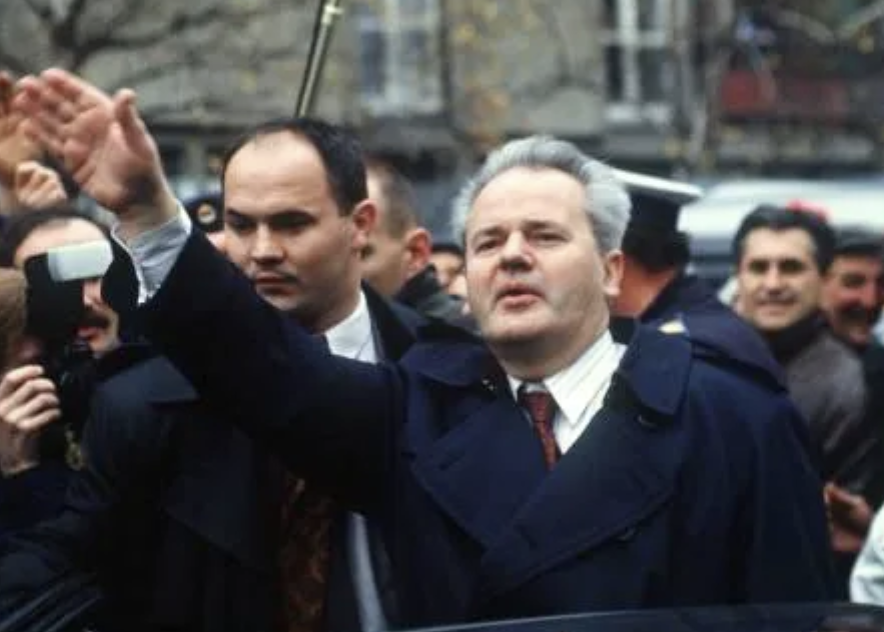

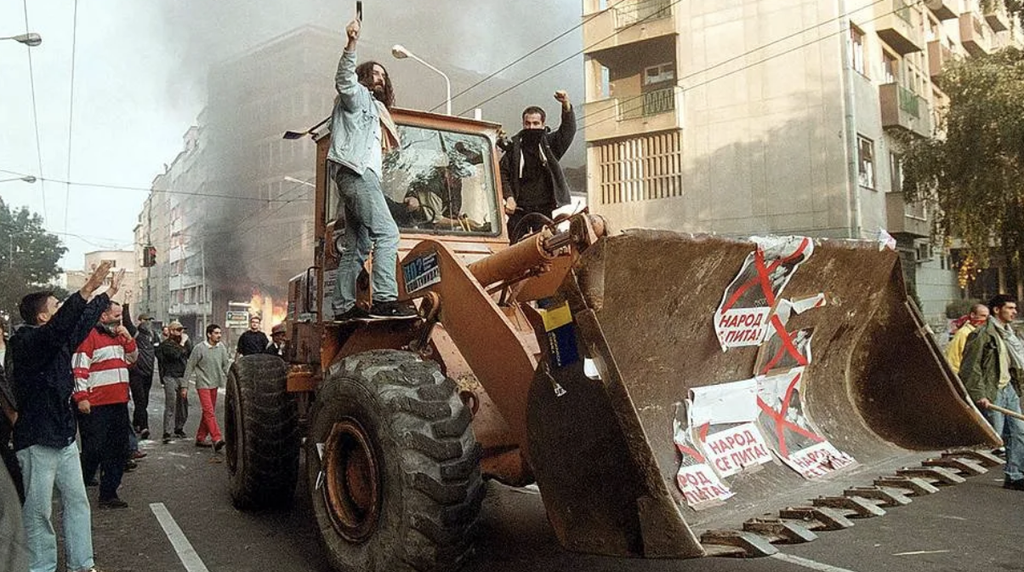

[figure not shown]

[figure not shown]

## Google bombing

- manipulating a search enginge algorithm to rank highly certain websites
- Examples:

## Google bombing

- manipulating a search enginge algorithm to rank highly certain websites
- Examples:
  - in 2006, Google searches for “failure” returned sites for George W. Bush’s biography

## Google bombing

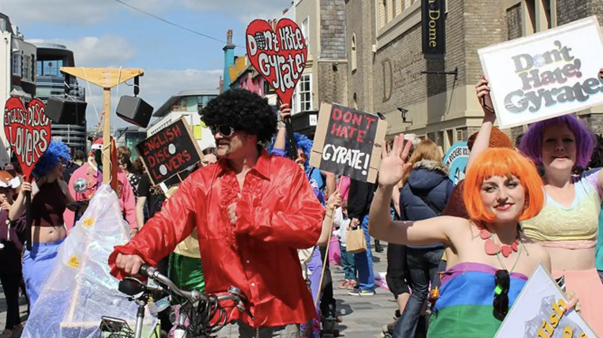

- manipulating a search enginge algorithm to rank highly certain websites
- Examples:
  - in 2006, Google searches for “failure” returned sites for George W. Bush’s biography
  - in 2012, UK activists got search results for “EDL” to return, instead of *English Defence League*, pages for the *English Disco Lovers*

## Google bombing

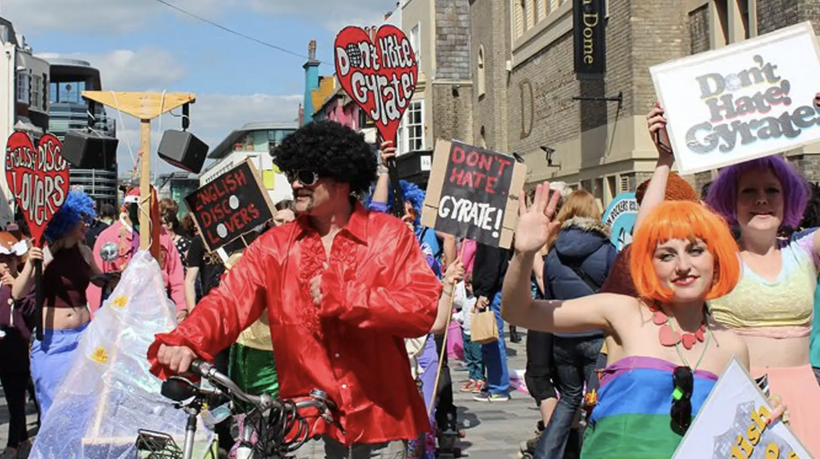

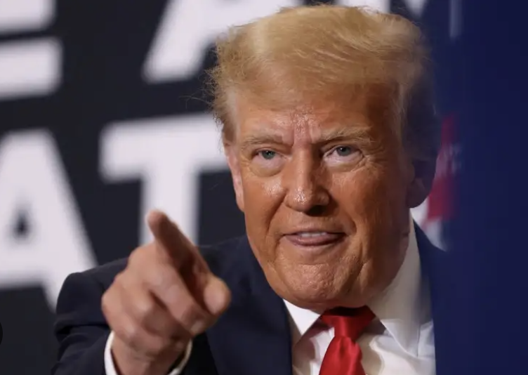

- manipulating a search enginge algorithm to rank highly certain websites
- Examples:
  - in 2006, Google searches for “failure” returned sites for George W. Bush’s biography
  - in 2012, UK activists got search results for “EDL” to return, instead of *English Defence League*, pages for the *English Disco Lovers*
  - in 2018, search results for “idiot” returned images of Donald Trump

## Diani (2000) - CMC’s democratizing impact

> the **overall democratizing impact of CMC may be severely hampered** by two types of resource constraints: while its contribution to networking among citizens’ organizations is undeniable, its contribution to the **operations of social control agencies**, the military, governments and corporations is – at least quantitatively – much greater; and access to CMC is at least for the time being heavily correlated to class and status

. . .

What do you think? Is CMC a democratizing tool?

. . .

The case of Hong Kong…

## Diani (2000) - CMC’s democratizing impact

[video not shown]

## Movement responses - online importance

online activity important to the movement

```javascript
m_online_importantCounts = aq.from(surveyResults)
  .groupby("m_online_important", "movement")
  .count()
  .objects();

plot_m_online_important = Plot.plot({
  marks: [
    Plot.frame({
      fill: "#f7f7f7",
      stroke: "black",
      strokeWidth: 1
    }),

    Plot.barY(m_online_importantCounts, {
      fx: "m_online_important",
      x: "movement",
      y: "count",
      fill: "movement",
      stroke: "white"
    })
  ],

  color: {
    domain: movementOrder,
    range: movementColors,
    legend: true,
    style: { fontSize: "20px" }
  },

  fx: {
    domain: likertOrder,
    label: "",
    tickRotate: -55
  },

  x: {
    domain: movementOrder,
    axis: null, // clears the entire x-axis (ticks and labels)
    // tickFormat: () => "",
    label: ""
  },

  y: {
    label: ""
  },

  marginBottom: 140,
  style: {
    width: 900,
    height: 500,
    fontSize: 20
  }
});
```

[interactive chart not shown]

most important use of online tools for movement

```javascript
m_most_important_useCounts = aq.from(surveyResults)
  .groupby("m_most_important_use", "movement")
  .count()
  .objects();

plot_m_most_important_use = Plot.plot({
  marks: [
    Plot.frame({
      fill: "#f7f7f7",
      stroke: "black",
      strokeWidth: 1
    }),

    Plot.barY(m_most_important_useCounts, {
      fx: "m_most_important_use",
      x: "movement",
      y: "count",
      fill: "movement",
      stroke: "white"
    })
  ],

  color: {
    domain: movementOrder,
    range: movementColors,
    legend: true,
    style: { fontSize: "20px" }
  },

  fx: {
    // domain: likertOrder,
    label: "",
    tickRotate: -45
  },

  x: {
    domain: movementOrder,
    axis: null, // clears the entire x-axis (ticks and labels)
    // tickFormat: () => "",
    label: ""
  },

  y: {
    label: ""
  },

  marginBottom: 250,
  style: {
    width: 900,
    height: 500,
    fontSize: 20
  }
});
```

[interactive chart not shown]

## Movement responses - linking to offline

new supporters first encounter the movement online

```javascript
m_first_encounter_onlineCounts = aq.from(surveyResults)
  .groupby("m_first_encounter_online", "movement")
  .count()
  .objects();

plot_m_first_encounter_online = Plot.plot({
  marks: [
    Plot.frame({
      fill: "#f7f7f7",
      stroke: "black",
      strokeWidth: 1
    }),

    Plot.barY(m_first_encounter_onlineCounts, {
      fx: "m_first_encounter_online",
      x: "movement",
      y: "count",
      fill: "movement",
      stroke: "white"
    })
  ],

  color: {
    domain: movementOrder,
    range: movementColors,
    legend: true,
    style: { fontSize: "20px" }
  },

  fx: {
    domain: ynmOrder,
    label: "",
    tickRotate: 0
  },

  x: {
    domain: movementOrder,
    axis: null, // clears the entire x-axis (ticks and labels)
    // tickFormat: () => "",
    label: ""
  },

  y: {
    label: ""
  },

  marginBottom: 130,
  style: {
    width: 900,
    height: 500,
    fontSize: 20
  }
});
```

[interactive chart not shown]

online leads to offline

```javascript
m_online_to_offlineCounts = aq.from(surveyResults)
  .groupby("m_online_to_offline", "movement")
  .count()
  .objects();

plot_m_online_to_offline = Plot.plot({
  marks: [
    Plot.frame({
      fill: "#f7f7f7",
      stroke: "black",
      strokeWidth: 1
    }),

    Plot.barY(m_online_to_offlineCounts, {
      fx: "m_online_to_offline",
      x: "movement",
      y: "count",
      fill: "movement",
      stroke: "white"
    })
  ],

  color: {
    domain: movementOrder,
    range: movementColors,
    legend: true,
    style: { fontSize: "20px" }
  },

  fx: {
    domain: likertOrder,
    label: "",
    tickRotate: -55
  },

  x: {
    domain: movementOrder,
    axis: null, // clears the entire x-axis (ticks and labels)
    // tickFormat: () => "",
    label: ""
  },

  y: {
    label: ""
  },

  marginBottom: 140,
  style: {
    width: 900,
    height: 500,
    fontSize: 20
  }
});
```

[interactive chart not shown]

## Movement responses - key platform

most important online platform

```javascript
m_important_platformCounts = aq.from(surveyResults)
  .groupby("m_important_platform", "movement")
  .count()
  .objects();

plot_m_important_platform = Plot.plot({
  marks: [
    Plot.frame({
      fill: "#f7f7f7",
      stroke: "black",
      strokeWidth: 1
    }),

    Plot.barY(m_important_platformCounts, {
      fx: "m_important_platform",
      x: "movement",
      y: "count",
      fill: "movement",
      stroke: "white"
    })
  ],

  color: {
    domain: movementOrder,
    range: movementColors,
    legend: true,
    style: { fontSize: "20px" }
  },

  fx: {
    // domain: likertOrder,
    label: "",
    tickRotate: -45
  },

  x: {
    domain: movementOrder,
    axis: null, // clears the entire x-axis (ticks and labels)
    // tickFormat: () => "",
    label: ""
  },

  y: {
    label: ""
  },

  marginBottom: 250,
  style: {
    width: 900,
    height: 500,
    fontSize: 20
  }
});
```

[interactive chart not shown]

## Movement responses - content moderation

movement affected by content moderation

```javascript
m_affected_by_content_moderationCounts = aq.from(surveyResults)
  .groupby("m_affected_by_content_moderation", "movement")
  .count()
  .objects();

plot_m_affected_by_content_moderation = Plot.plot({
  marks: [
    Plot.frame({
      fill: "#f7f7f7",
      stroke: "black",
      strokeWidth: 1
    }),

    Plot.barY(m_affected_by_content_moderationCounts, {
      fx: "m_affected_by_content_moderation",
      x: "movement",
      y: "count",
      fill: "movement",
      stroke: "white"
    })
  ],

  color: {
    domain: movementOrder,
    range: movementColors,
    legend: true,
    style: { fontSize: "20px" }
  },

  fx: {
    domain: ynmOrder,
    label: "",
    tickRotate: 0
  },

  x: {
    domain: movementOrder,
    axis: null, // clears the entire x-axis (ticks and labels)
    // tickFormat: () => "",
    label: ""
  },

  y: {
    label: ""
  },

  marginBottom: 130,
  style: {
    width: 900,
    height: 500,
    fontSize: 20
  }
});
```

[interactive chart not shown]

## Movement responses - collective identity

Online participation gives supporters a sense of belonging

```javascript
m_online_brings_belongingCounts = aq.from(surveyResults)
  .groupby("m_online_brings_belonging", "movement")
  .count()
  .objects();

plot_m_online_brings_belonging = Plot.plot({
  marks: [
    Plot.frame({
      fill: "#f7f7f7",
      stroke: "black",
      strokeWidth: 1
    }),

    Plot.barY(m_online_brings_belongingCounts, {
      fx: "m_online_brings_belonging",
      x: "movement",
      y: "count",
      fill: "movement",
      stroke: "white"
    })
  ],

  color: {
    domain: movementOrder,
    range: movementColors,
    legend: true,
    style: { fontSize: "20px" }
  },

  fx: {
    domain: likertOrder,
    label: "",
    tickRotate: -55
  },

  x: {
    domain: movementOrder,
    axis: null, // clears the entire x-axis (ticks and labels)
    // tickFormat: () => "",
    label: ""
  },

  y: {
    label: ""
  },

  marginBottom: 140,
  style: {
    width: 900,
    height: 500,
    fontSize: 20
  }
});
```

[interactive chart not shown]

# Online replacing offline activism

- Volk (2021) - Political Performances of Control During COVID-19: Controlling and Contesting Democracy in Germany
  - research design
    - brief intro to interpretivism
  - PEGIDA online
  - findings
- discussion topic from the news

[Boburnham Inside GIF](https://tenor.com/view/boburnham-inside-netflix-internet-computer-gif-21887509)from [Boburnham GIFs](https://tenor.com/search/boburnham-gifs)

## Volk (2021) research design

> explores how political actors in Germany performed control during the first wave of the COVID-19 pandemic, comparing the performances of control by two institutional actors and one counter-institutional grassroots actor
- data generated through **qualitative-interpretive methodology** (familiar with this?)
  - online ethnography
  - comparative analysis
  - observation of in-person an “anti-lockdown” demonstration and [virtual protest](https://www.opendemocracy.net/en/countering-radical-right/under-lockdown-germanys-pegida-goes-to-youtube/)

## A *very* brief introduction to interpretive research

- **Interpretivism** - philosophical perspective that *reality and knowledge are socially constructed*
  - cf. (post-)positivist perspectives: there is an ‘objective reality’ that can be measured and tested
    - Galileo Galilei: ‘*Count what is countable, measure what is measurable and what is not measurable, make measurable*.’
  - has **epistemological consequences**: i.e., if reality is socially constructed, in what ways can we obtain knowledge about it?
    - ANSWER: techniques to identify and assess the **meanings that people attach to events, actions, etc.**
- **interpretivist** findings dependent on researcher’s interpretation
  - problematic (according to some): difficulty of *replicability*, easy for ‘*bias*’ to slant interpretation, difficult to *generalise*

## Volk (2021) - PEGIDA ‘virtueller Abendspaziergang’

[figure not shown]

## Volk (2021) - findings (1)

```r
volk <- data.frame(
  Cases = c("Merkel", "Kretschmer", "PEGIDA"),
  Habitus = c("informer of the people",
              "Interlocutor of the people",
              "Enlightened leader of the people"),
  Communication_modes = c("monological, unidirectional",
                          "Dialogical, multidirectional",
                          "Monological and plurilogical, unidirectional"),
  Emotional_tone = c(
    "<span style='color:red; font-weight:bold;'>Empathic, caring</span>",
    "<span style='color:red; font-weight:bold;'>Engaged, brave</span>",
    "<span style='color:red; font-weight:bold;'>Enraged, mocking</span>"
  ),
  Intended_audience = c(
    "National media audience",
    "Local immediate audience; regional and national media audience",
    "Regional, national, and transnational media audience"
  ),
  Transmission_mode = c(
    "Conventional media",
    "New media; partially immediate",
    "New media"
  )
)

volk_tab1 <- kable(volk, "html", escape = FALSE,
      col.names = c("Cases", "Habitus", "Communication modes",
                    "Emotional tone", "Intended audience",
                    "Transmission mode")) %>%
  kable_styling(full_width = FALSE, bootstrap_options = c("striped"), font_size = 24) %>%
  column_spec(2, width = "1.8cm") %>%
  column_spec(3, width = "2cm") %>%
  column_spec(4, width = "1.4cm") %>%
  column_spec(5, width = "2cm") %>%
  column_spec(6, width = "2cm") %>%
  add_header_above(c(" " = 1,
                     "Style" = 3,
                     "Intended audience" = 1,
                     "Transmission mode" = 1))
volk_tab1
```

| Cases | Style Habitus | Style Communication modes | Style Emotional tone | Intended audience | Transmission mode |
| --- | --- | --- | --- | --- | --- |
| Merkel | informer of the people | monological, unidirectional | Empathic, caring | National media audience | Conventional media |
| Kretschmer | Interlocutor of the people | Dialogical, multidirectional | Engaged, brave | Local immediate audience; regional and national media audience | New media; partially immediate |
| PEGIDA | Enlightened leader of the people | Monological and plurilogical, unidirectional | Enraged, mocking | Regional, national, and transnational media audience | New media |

## Volk (2021) - findings (1)

how (if at all) do you recall Merkel’s televised address at the start of the pandemic? (https://www.youtube.com/watch?v=4YS20YQbVE4&pp=ygUXbWVya2VsIGNvcm9uYSBhbnNwcmFjaGU%3D)

```r
volk_tab1
```

| Cases | Style Habitus | Style Communication modes | Style Emotional tone | Intended audience | Transmission mode |
| --- | --- | --- | --- | --- | --- |
| Merkel | informer of the people | monological, unidirectional | Empathic, caring | National media audience | Conventional media |
| Kretschmer | Interlocutor of the people | Dialogical, multidirectional | Engaged, brave | Local immediate audience; regional and national media audience | New media; partially immediate |
| PEGIDA | Enlightened leader of the people | Monological and plurilogical, unidirectional | Enraged, mocking | Regional, national, and transnational media audience | New media |

## Volk (2021) - findings (2)

Styles of communication align with implicit and/or explicit understanding of democracy:

```r
volk2 <- data.frame(
  Cases = c("Merkel", "Kretschmer", "PEGIDA"),
  Dominant_meaning = c("Openness of the decision-making procedures",
                       "Civil rights, especially freedom of speech",
                       "Civil rights, especially freedom of speech; Rule of law"),
  Hierarchical_dynamics = c("Top-down", "Bottom-up", "Bottom-up"),
  Safeguarded_by = c("Governmental accountability and transparency",
                     "Dialogue between elected representatives and citizens",
                     "Citizens’ activism and protest")
)

# Create kable table
kable(volk2,
      col.names = c("Cases", "Dominant meaning", "Hierarchical dynamics", "Safeguarded by"),
      format = "pipe") %>%
  kable_styling(full_width = FALSE, bootstrap_options = c("striped"), font_size = 26) %>%
  column_spec(1, width = "1.8cm") %>%
  column_spec(2, width = "7cm") %>%
  column_spec(3, width = "2cm") %>%
  column_spec(4, width = "7cm") %>%
  add_header_above(c(" " = 1,
                     "Floating meanings of 'democracy'" = 3))
```

| Cases | Floating meanings of 'democracy' Dominant meaning | Floating meanings of 'democracy' Hierarchical dynamics | Floating meanings of 'democracy' Safeguarded by |
| --- | --- | --- | --- |
| Merkel | Openness of the decision-making procedures | Top-down | Governmental accountability and transparency |
| Kretschmer | Civil rights, especially freedom of speech | Bottom-up | Dialogue between elected representatives and citizens |
| PEGIDA | Civil rights, especially freedom of speech; Rule of law | Bottom-up | Citizens’ activism and protest |

## Volk (2021) - key assertions

1. Political performances of control in Germany during the COVID-19 pandemic were characterised by constant appeals to the **idea(l) of democracy**.
2. Control is something that needs to be constantly (re-)articulated in political performances.
3. Performances are carefully staged and purposefully disseminated discursive events that aim to articulate political meaning.

## Discussion point from the news

**Meta (Facebook, Instagram, Threads—3 billion users worldwide) ‘[drastically reduces factcheckers and recommends more political content](https://www.theguardian.com/technology/2025/jan/07/meta-facebook-instagram-threads-mark-zuckerberg-remove-fact-checkers-recommend-political-content)’**

- Zuckerberg intended to “*dramatically reduce the amount of **censorship***” (framing contest: ‘censorship’ vs. ‘content moderation’)
- Zuckerberg to “*work with President Trump to push back on governments around the world that are going after American companies and pushing to censor more*”. He cited Europe as a place with “*an ever-increasing number of laws institutionalising censorship and making it difficult to build anything innovative*”

## Reconnecting online activism to (offline) impact

Zeynep Tufekci (UNC Chapel Hill): How online social movements translate to offline results

[video not shown]

## Two recent findings from research on online movement activity

- influencers on social media can have a massive impact on elections and other political events (e.g., Rezo anti-CDU video in 2019: Klüver (2024))
- deplatforming from mainstream social media platforms has a major impact on movement actors and activists (e.g., Rauchfleisch and Kaiser 2024)

# Any questions, concerns, feedback for this class?

Anonymous feedback here: https://forms.gle/AjHt6fcnwZxkSg4X8

Alternatively, please send me an email: m.zeller@lmu.de

Questions about movements next meeting: (1) How influential has the movement been? (2) Does participation in the movement have lasting effects on participants’ lives? (3) Has the movement inspired the formation of new organisations or initiatives? (4) Which political area has been most affected by the movement? (5) Which cultural impact has been most significant? (6) Which factor best explains this movement’s success?

## References

Diani, Mario. 2000. “Social Movement Networks Virtual and Real.” *Information, Communication & Society* 3 (3): 386–401. https://doi.org/10.1080/13691180051033333.

Klüver, Heike. 2024. “Social Influencers and Election Outcomes.” *Comparative Political Studies*, December, 00104140241306955. https://doi.org/10.1177/00104140241306955.

Rauchfleisch, Adrian, and Jonas Kaiser. 2024. “The Impact of Deplatforming the Far Right: An Analysis of YouTube and BitChute.” *Information, Communication & Society*, May, 1–19. https://doi.org/10.1080/1369118X.2024.2346524.

Volk, Sabine. 2021. “Political Performances of Control During COVID-19: Controlling and Contesting Democracy in Germany.” *Frontiers in Political Science* 3 (June): 1–16. https://doi.org/10.3389/fpos.2021.654069.